# Estimating the early death toll of COVID-19 in the United States

Dan Weinberger

4/3/2020

## Abstract

Mortality data on deaths due to pneumonia & influenza through the week ending 2020-03-28

*Background* Tracking the severity and public health impact of emerging diseases, such as the novel coronavirus diseases COVID-19, is a critical need. These efforts are often hampered by testing issues and reporting lags for key epidemiological data. Evaluating unexplained increases in deaths attributed to non-specific causes, such as pneumonia, can provide a more complete picture of the burden caused by COVID-19.

*Methods* We evaluated increases in the occurrence of deaths due to P&I above a seasonal baseline across the United States and compared the rate of excess deaths to reported rates of death due to COVID-19, as well as state-level coronavirus testing rates and excess rates of influenza-like illness.

*Conclusions* Given the lack of consistent virological testing, tracking spikes in deaths due to non-specific causes provides the most complete estimate of the burden of COVID-19. This approach provides a framework for tracking the progression of the epidemic and its public health impact.

## Figure 1: Observed weekly death rate vs seasonal baseline (+/-95% Prediction Interval)

The black line shows the observed proportion of deaths that were due to Pneumonia & Influenza (P&I) per week. The red line and shaded area represent the 95% Prediction Interval. The latest P&I data is for the week ending 2020-03-28.

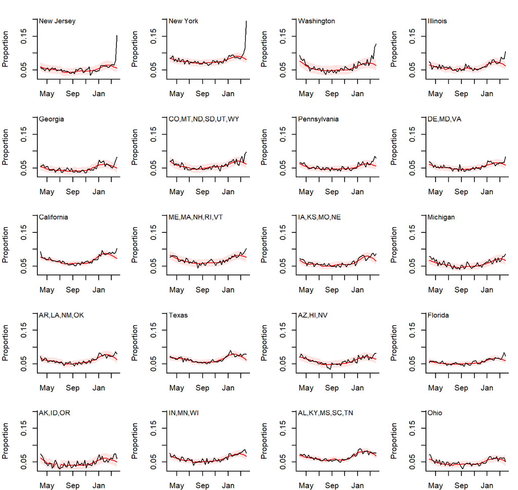

## Figure 2: Observed deaths/expected deaths by state

Excess Deaths due to pneumonia and influenza

These plots show the Observed/Expected number of deaths due to pneumonia and influenza in each week for the 2019-20 year (red) compared to previous years (gray). Values close to 1 indicate that the values for that week are close to what would be expected based on the time of year and influenza activity.

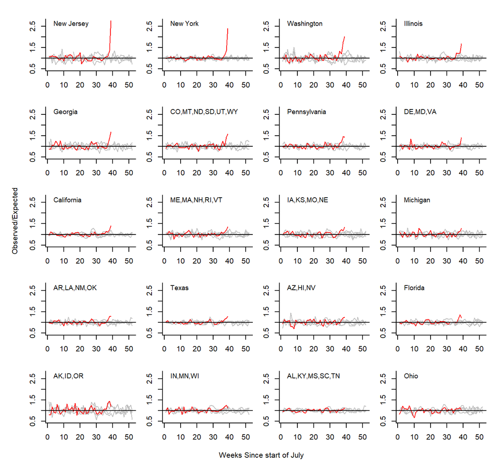

## Figure 3: Reported number of COVID-19 deaths,compared with the excess deaths due to pneumonia and influenza in each week, by state.

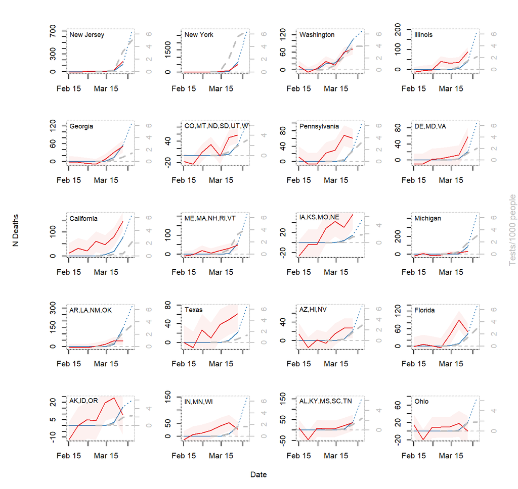

## Table 1: Excess P&I deaths and reported deaths due to COVID-19

| Observed and Excess deaths due to pneumonia & influenza, and COVID-19, from February 9, 2020 through Mar 28, 2020 State | Observed and Excess deaths due to pneumonia & influenza, and COVID-19, from February 9, 2020 through Mar 28, 2020 Total P&I deaths | Observed and Excess deaths due to pneumonia & influenza, and COVID-19, from February 9, 2020 through Mar 28, 2020 Excess P&I deaths | Observed and Excess deaths due to pneumonia & influenza, and COVID-19, from February 9, 2020 through Mar 28, 2020 Reported COVID-19 deaths | Observed and Excess deaths due to pneumonia & influenza, and COVID-19, from February 9, 2020 through Mar 28, 2020 Excess P&I deaths/1,000,000 people |
| --- | --- | --- | --- | --- |
| NY | 2654 | 619(525, 713) | 728 | 31.8 (27, 36.7) |
| WA | 736 | 187(139, 235) | 207 | 24.6 (18.2, 30.9) |
| NJ | 860 | 206(154, 258) | 140 | 23.2 (17.4, 29) |
| IL | 1266 | 185(117, 253) | 47 | 14.6 (9.2, 20) |
| PA | 1237 | 182(115, 249) | 34 | 14.2 (9, 19.4) |
| CA | 3428 | 398(285, 511) | 101 | 10.1 (7.2, 12.9) |
| ME,MA,NH,RI,VT | 1258 | 114(44, 183) | 59 | 10.1 (3.9, 16.3) |
| IA,KS,MO,NE | 1498 | 124(47, 200) | 20 | 8.7 (3.3, 14.2) |
| CO,MT,ND,SD,UT,WY | 953 | 106(46, 166) | 36 | 8.7 (3.8, 13.6) |
| FL | 2039 | 181(94, 268) | 54 | 8.4 (4.4, 12.5) |
| IN,MN,WI | 1795 | 150(66, 234) | 49 | 8.2 (3.6, 12.9) |
| AK,ID,OR | 466 | 50(9, 92) | 19 | 7.4 (1.3, 13.6) |
| AR,LA,NM,OK | 1402 | 95(21, 169) | 158 | 6.9 (1.5, 12.3) |
| GA | 677 | 67(17, 117) | 69 | 6.3 (1.6, 11.1) |
| TX | 2105 | 176(86, 266) | 27 | 6.1 (3, 9.2) |
| AZ,HI,NV | 994 | 62(0, 125) | 25 | 5.3 (0, 10.6) |
| DE,MD,VA | 1188 | 67(-2, 135) | 25 | 4.3 (-0.2, 8.7) |
| OH | 973 | 44(-19, 106) | 25 | 3.7 (-1.6, 9.1) |
| MI | 979 | 37(-27, 101) | 92 | 3.7 (-2.7, 10.1) |
| AL,KY,MS,SC,TN | 2661 | 48(-57, 152) | 43 | 2 (-2.4, 6.3) |

## Figure 4: Compare Excess P&I mortality vs Excess ILI

Here we compare the observed vs expected number of deaths due to pneumonia and influenza in each week compare to the observed vs expected number of outpatient visits for influenza-like illness (ILI) in each week. we would expect ILI (blue line) to increase earlier than deaths (red line)

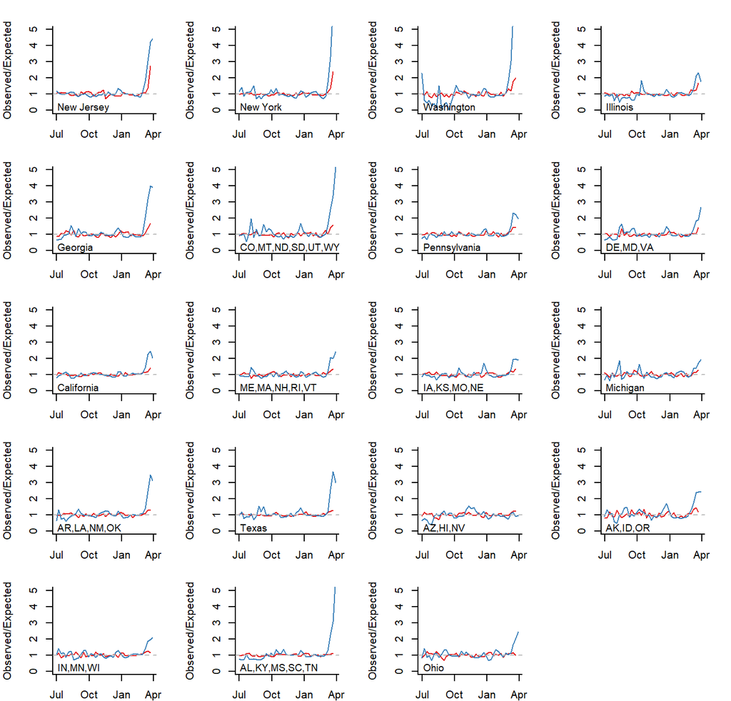

## Supplementary Table 1: Excess deaths by week across the US, compared with official numbers from NCHS

| Table S1: Comparison of data sources: Observed and Excess deaths due to pneumonia & influenza, and COVID-19, from February 9, 2020 through Mar 28, 2020 Week ending | Table S1: Comparison of data sources: Observed and Excess deaths due to pneumonia & influenza, and COVID-19, from February 9, 2020 through Mar 28, 2020 Total P&I deaths | Table S1: Comparison of data sources: Observed and Excess deaths due to pneumonia & influenza, and COVID-19, from February 9, 2020 through Mar 28, 2020 Excess P&I deaths | Table S1: Comparison of data sources: Observed and Excess deaths due to pneumonia & influenza, and COVID-19, from February 9, 2020 through Mar 28, 2020 NCHS Reported COVID-19 Deaths, with pneumonia code | Table S1: Comparison of data sources: Observed and Excess deaths due to pneumonia & influenza, and COVID-19, from February 9, 2020 through Mar 28, 2020 NCHS Reported COVID-19 Deaths | Table S1: Comparison of data sources: Observed and Excess deaths due to pneumonia & influenza, and COVID-19, from February 9, 2020 through Mar 28, 2020 All reported COVID-19 deaths (covidtracking.com) |
| --- | --- | --- | --- | --- | --- |
| 2020-02-15 | 3971 | -70(-201, 61) | 0 | 0 | 0 |
| 2020-02-22 | 3867 | -131(-261, 0) | 0 | 0 | 0 |
| 2020-02-29 | 3998 | 66(-63, 195) | 3 | 5 | 1 |
| 2020-03-07 | 4092 | 271(143, 398) | 11 | 19 | 22 |
| 2020-03-14 | 4046 | 454(331, 577) | 22 | 44 | 36 |
| 2020-03-21 | 4317 | 885(765, 1005) | 200 | 435 | 229 |
| 2020-03-28 | 4877 | 1622(1505, 1739) | 928 | 2034 | 1670 |

## Figure S1: Excess all-cause deaths

Now instead of modeling the proportion of deaths that were due to pneumonia and influenza, we will model all-caused deaths, using the proportion under-reporting as the denominator

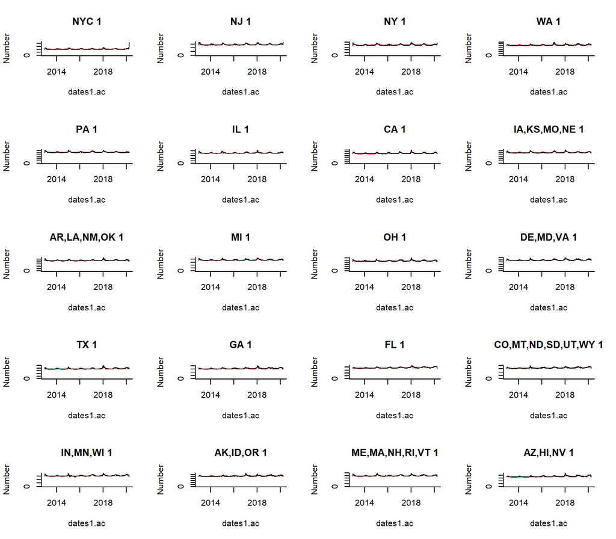

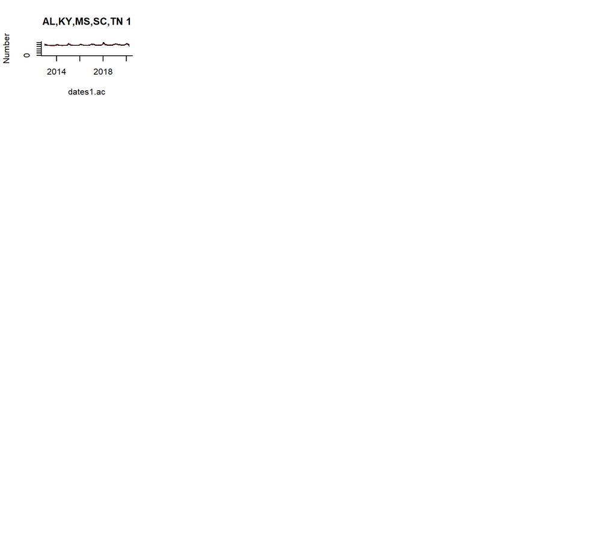

## Figure S2: Excess all-cause deaths for NY state (incl NYC) vs Excess deaths due to pneumonia and influenza

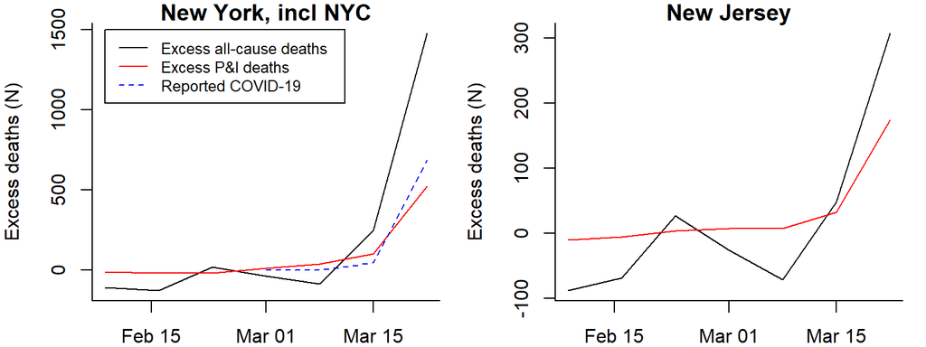

```
#> [1] 0.5667752
#> [1] 0.3523035
```

## Figure S3: NYC only data P&I vs all-cause excess deaths

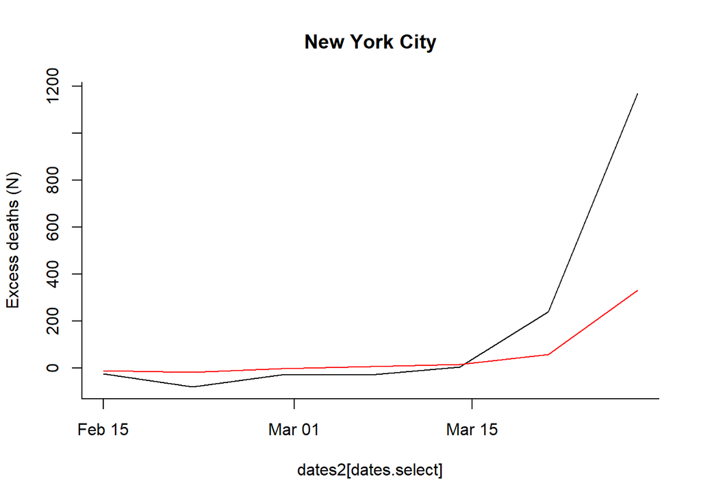

Ratio of all-cause vs P&I deaths in NYC. In NYC, only 25% of excess deaths were coded as P&I

```
#> [1] 0.237500 0.283148
#> [1] 1409
```

## Table S3: Proportion of COVID-19 deaths with a pneumonia code, by state

|  | State | NCHS Reported COVID-19 Deaths | NCHS Reported COVID-19 Deaths, with pneumonia code | Proportion with pneumonia |
| --- | --- | --- | --- | --- |
| 25 | Total US | 6930 | 3161 | 0.4561328 |
| 26 | Alabama | 17 | 6 | 0.3529412 |
| 27 | Alaska | 1 | 1 | 1.0000000 |
| 28 | Arizona | 26 | 13 | 0.5000000 |
| 29 | Arkansas | 10 | 2 | 0.2000000 |
| 30 | California | 187 | 102 | 0.5454545 |
| 31 | Colorado | 107 | 60 | 0.5607477 |
| 33 | Delaware | 2 | 2 | 1.0000000 |
| 34 | District of Columbia | 5 | 5 | 1.0000000 |
| 35 | Florida | 157 | 93 | 0.5923567 |

[output cut: 40 more lines]

|  | State | NCHS Reported COVID-19 Deaths | NCHS Reported COVID-19 Deaths, with pneumonia code | Proportion with pneumonia |
| --- | --- | --- | --- | --- |
| 25 | Total US | 6930 | 3161 | 0.46 |
| 26 | Alabama | 17 | 6 | 0.35 |
| 27 | Alaska | 1 | 1 | 1 |
| 28 | Arizona | 26 | 13 | 0.5 |
| 29 | Arkansas | 10 | 2 | 0.2 |
| 30 | California | 187 | 102 | 0.55 |
| 31 | Colorado | 107 | 60 | 0.56 |
| 33 | Delaware | 2 | 2 | 1 |
| 34 | District of Columbia | 5 | 5 | 1 |
| 35 | Florida | 157 | 93 | 0.59 |
| 36 | Georgia | 74 | 42 | 0.57 |
| 37 | Hawaii | 1 | 0 | 0 |
| 38 | Idaho | 13 | 4 | 0.31 |
| 39 | Illinois | 77 | 47 | 0.61 |
| 40 | Indiana | 43 | 19 | 0.44 |
| 41 | Iowa | 12 | 2 | 0.17 |
| 42 | Kansas | 9 | 3 | 0.33 |
| 43 | Kentucky | 6 | 3 | 0.5 |
| 44 | Louisiana | 154 | 64 | 0.42 |
| 45 | Maine | 10 | 5 | 0.5 |
| 46 | Maryland | 75 | 42 | 0.56 |
| 47 | Massachusetts | 172 | 85 | 0.49 |
| 48 | Michigan | 309 | 142 | 0.46 |
| 49 | Minnesota | 17 | 6 | 0.35 |
| 50 | Mississippi | 34 | 17 | 0.5 |
| 51 | Missouri | 22 | 9 | 0.41 |
| 52 | Montana | 3 | 1 | 0.33 |
| 53 | Nebraska | 3 | 2 | 0.67 |
| 54 | Nevada | 27 | 21 | 0.78 |
| 55 | New Hampshire | 15 | 8 | 0.53 |
| 56 | New Jersey | 593 | 303 | 0.51 |
| 57 | New Mexico | 1 | 0 | 0 |
| 58 | New York | 1130 | 650 | 0.58 |
| 59 | New York City | 2862 | 1065 | 0.37 |
| 61 | North Dakota | 1 | 0 | 0 |
| 62 | Ohio | 8 | 4 | 0.5 |
| 63 | Oklahoma | 17 | 5 | 0.29 |
| 64 | Oregon | 21 | 13 | 0.62 |
| 65 | Pennsylvania | 220 | 98 | 0.45 |
| 66 | Rhode Island | 1 | 1 | 1 |
| 67 | South Carolina | 36 | 13 | 0.36 |
| 68 | South Dakota | 4 | 1 | 0.25 |
| 69 | Tennessee | 25 | 11 | 0.44 |
| 70 | Texas | 47 | 18 | 0.38 |
| 71 | Utah | 8 | 3 | 0.38 |
| 72 | Vermont | 17 | 6 | 0.35 |
| 73 | Virginia | 39 | 15 | 0.38 |
| 74 | Washington | 278 | 142 | 0.51 |
| 76 | Wisconsin | 34 | 7 | 0.21 |
| 78 | Puerto Rico | 18 | 13 | 0.72 |

##Table S3: Do not adjust for underreporting of deaths

| Observed and Excess deaths due to pneumonia & influenza, and COVID-19, from February 9, 2020 through Mar 28, 2020 State | Observed and Excess deaths due to pneumonia & influenza, and COVID-19, from February 9, 2020 through Mar 28, 2020 Excess P&I deaths (unadjusted) | Observed and Excess deaths due to pneumonia & influenza, and COVID-19, from February 9, 2020 through Mar 28, 2020 Excess P&I deaths (adjusted) | Observed and Excess deaths due to pneumonia & influenza, and COVID-19, from February 9, 2020 through Mar 28, 2020 Reported COVID-19 deaths |
| --- | --- | --- | --- |
| NY | 619(525, 713) | 619(525, 713) | 728 |
| CA | 392(279, 505) | 398(286, 511) | 101 |
| NJ | 206(154, 258) | 206(154, 258) | 140 |
| WA | 187(139, 235) | 187(139, 235) | 207 |
| IL | 185(117, 253) | 185(117, 253) | 47 |
| FL | 181(94, 268) | 181(94, 268) | 54 |
| TX | 159(71, 247) | 176(87, 264) | 27 |
| PA | 156(96, 216) | 182(122, 242) | 34 |
| IN,MN,WI | 146(62, 230) | 150(66, 234) | 49 |
| ME,MA,NH,RI,VT | 110(41, 179) | 114(44, 183) | 59 |
| IA,KS,MO,NE | 110(35, 185) | 124(48, 199) | 20 |
| CO,MT,ND,SD,UT,WY | 102(42, 162) | 106(46, 166) | 36 |
| AR,LA,NM,OK | 74(2, 146) | 95(23, 166) | 158 |
| DE,MD,VA | 65(-4, 134) | 67(-2, 135) | 25 |
| AZ,HI,NV | 61(-1, 123) | 62(0, 125) | 25 |
| GA | 46(-3, 95) | 67(19, 116) | 69 |
| AK,ID,OR | 44(4, 84) | 50(10, 91) | 19 |
| AL,KY,MS,SC,TN | 39(-64, 142) | 48(-56, 151) | 43 |
| MI | 37(-27, 101) | 37(-27, 101) | 92 |
| OH | 34(-23, 91) | 44(-13, 101) | 25 |

| Excess deaths due to pneumonia & influenza from February 9, 2020 through Mar 28, 2020 with or without adjustment for delayed reporting state | Excess deaths due to pneumonia & influenza from February 9, 2020 through Mar 28, 2020 with or without adjustment for delayed reporting Excess P&I (unadjusted) | Excess deaths due to pneumonia & influenza from February 9, 2020 through Mar 28, 2020 with or without adjustment for delayed reporting Excess P&I (adjusted for reporting delay) |
| --- | --- | --- |
| NY | 514(420, 608) | 619(525, 713) |
| CA | 371(258, 484) | 398(286, 511) |
| NJ | 206(154, 258) | 206(154, 258) |
| WA | 156(108, 204) | 187(139, 235) |
| IL | 165(97, 233) | 185(117, 253) |
| PA | 75(15, 135) | 182(122, 242) |
| FL | 180(93, 267) | 181(94, 268) |
| TX | 88(0, 177) | 176(87, 264) |
| IN,MN,WI | 101(17, 184) | 150(66, 234) |
| IA,KS,MO,NE | 60(-15, 135) | 124(48, 199) |
| ME,MA,NH,RI,VT | 63(-7, 132) | 114(44, 183) |
| CO,MT,ND,SD,UT,WY | 53(-7, 113) | 106(46, 166) |
| AR,LA,NM,OK | 67(-5, 138) | 95(23, 166) |
| GA | 40(-9, 88) | 67(19, 116) |
| DE,MD,VA | 39(-29, 108) | 67(-2, 135) |
| AZ,HI,NV | 47(-15, 109) | 62(0, 125) |
| AK,ID,OR | 17(-23, 58) | 50(10, 91) |
| AL,KY,MS,SC,TN | 42(-61, 145) | 48(-56, 151) |
| OH | 13(-44, 70) | 44(-13, 101) |
| MI | 46(-18, 110) | 37(-27, 101) |